# Partial Dependence Profiles and Accumulated Local Dependence for explaining models on the Titanic dataset

author: Witalis Domitrz witekdomitrz@gmail.com

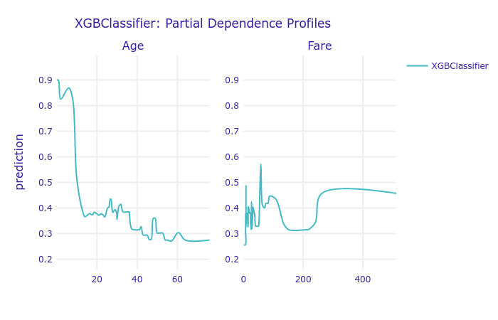

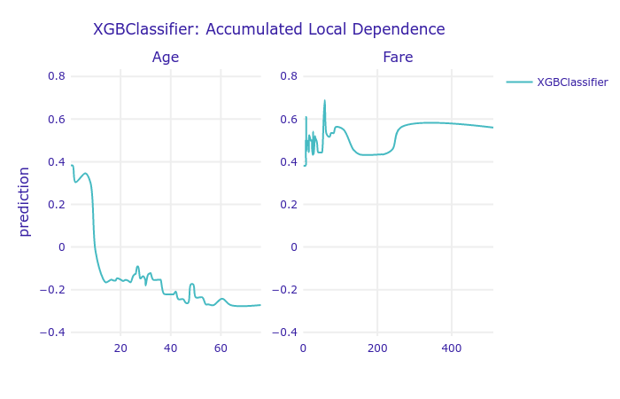

The first model well presents the importance of the age - the children were generally much more likely to survive. The most likely to survive were the newborns, then the possibility goes down for children that were not with their mothers all the time and raises a little bit as the children became more mature. Then there is a huge difference of more than 0.45 percent between the children and adults. The model also points that the younger adults are more likely to survive then those older than 38 years old. There are some minor fluctuations that might be a good point for the future investigation. The fare profile is also quite interesting. We see very unstable profile for the lower fare - it might be caused by some over fitting. It might be a good idea to try mark the fare as a range (eg. fare between 0£ and 5£, between 5£ and 20£ etc.). There is also an interesting fenomena that the probability of the survival is smaller in a fare range between 120£ and 250£ that I don't fully understand - it might be the price range for the adults in the second class. The lower fare for the children might have caused the instability of low fare profile and the high fare profile probably represents the passengers from the first class.

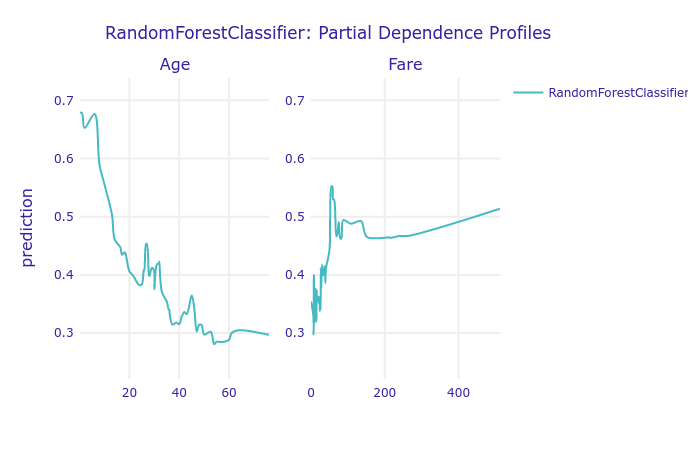

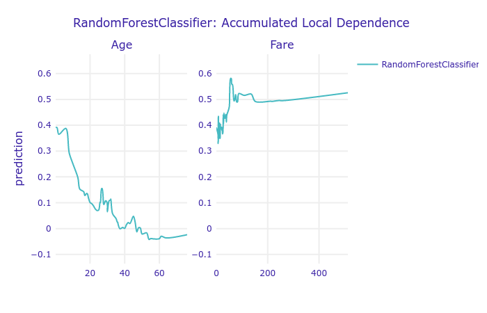

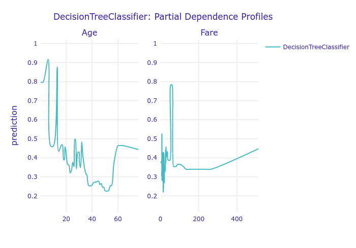

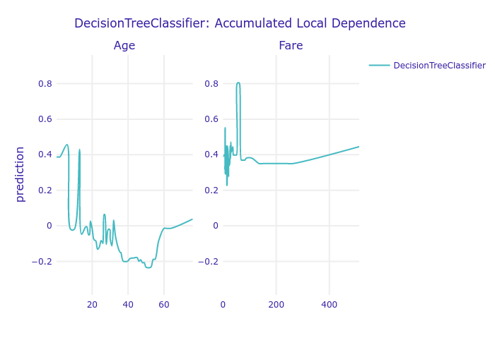

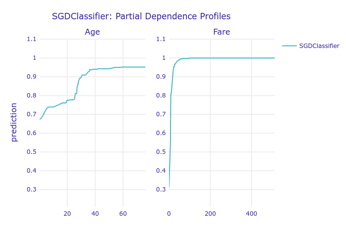

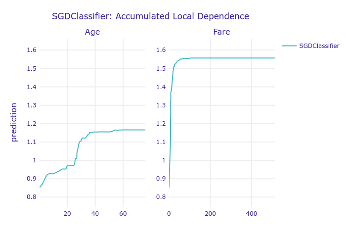

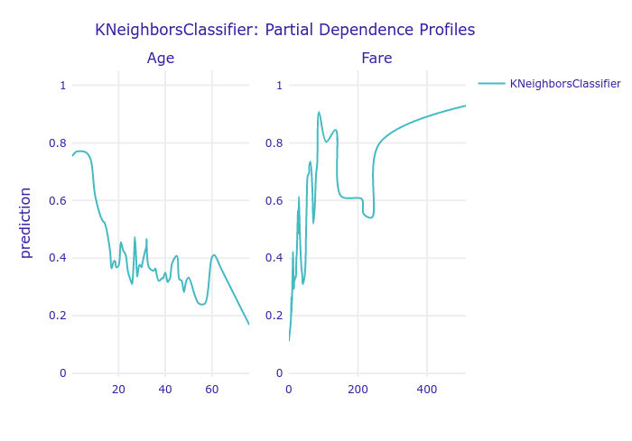

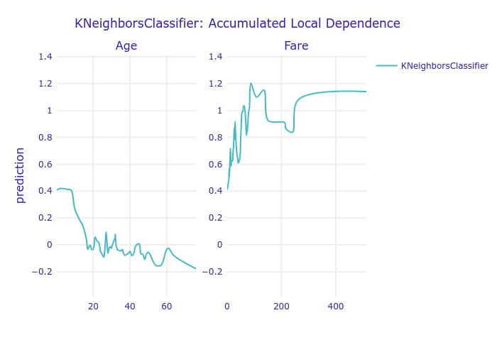

The random forest and k-nearest neighbours models present similar, but a little bit smoother profile of the age - the children are most likely to survive and the older the adults, the lower the probability of survival. Both plots presents similar tendency and their fits the models behaviours. The profile of the age for decision tree presents some strange anomalies - the huge drop for the ~10 years old children, than back again high possibility of survival. It might be a flaw in the model, which is quite good guess, especially when comparing it with the profiles of models with higher accuracy. The SGD model seems to have much different profile than the others and it might be caused by the low capacity of the model, which was unable to model interactions between variables. For the fare situation with SGD is similar which even more causes doubts about the model's relevance. The profiles of the fare for random forest and decision tree present similar tendencies with visible point of high probability of survival in one point (which we see at a glance for the decision tree, but it is also visible for the random forest). The interesting thing is that the k-nearest neighbours model presents similar tendency to the XGB model - much lower survival probability for a range of fare from 150£ up to 250£.

# Appendix

## Preparation

### Install modules

```python
!pip install dalex
```

### Download the data

```python
!wget http://students.mimuw.edu.pl/~wd393711/iml/titanic.zip
!unzip -o titanic.zip
!rm titanic.zip
```

### Prepare the data

```python
import numpy as np
import pandas as pd

used_columns = ['Pclass', 'Sex', 'Age', 'SibSp', 'Parch', 'Fare', 'Embarked', 'Survived']
X_columns = ['Pclass', 'Age', 'SibSp', 'Parch', 'Fare', 'Sex_male', 'Embarked_C', 'Embarked_Q', 'Embarked_S']
Y_columns = ['Survived']

def load_data(fn):
    return pd.read_csv(fn).set_index('PassengerId')

def to_array(data):
    return pd.get_dummies(data).astype(dtype='float32')

def data_preprocessing():
    global train, test
    train = load_data('./train.csv')
    test = load_data('./gender_submission.csv').join(load_data('./test.csv'))

    train['is_train'] = True
    test['is_train'] = False
    data = pd.concat([train, test])

    # Replace missing values with mean
    data.fillna(data.mean(), inplace=True)

    # Split test and train
    train, test = data[data['is_train']], data[data['is_train'] == False]

    # No unused columns
    train, test = train[used_columns], test[used_columns]

    train, test = to_array(train), to_array(test)
data_preprocessing()


def split_to_x_y(data):
    return to_array(data[X_columns]), to_array(data[Y_columns])

def get_data():
    return split_to_x_y(train), split_to_x_y(test)

def unlabel_data(*sets):
    return ((part.values for part in subset) for subset in sets)
```

```python
(train_x, train_y), (test_x, test_y) = get_data()
```

## 1.

For the selected data set, train at least one tree-based ensemble model (random forest, gbm, catboost or any other boosting)

```python
from xgboost import XGBClassifier
```

### Create a model

```python
model1 = XGBClassifier(base_score=0.5, booster='gbtree', colsample_bylevel=1,
                       colsample_bynode=1, colsample_bytree=1, gamma=0,
                       learning_rate=0.1, max_delta_step=0, max_depth=4,
                       min_child_weight=1, missing=None, n_estimators=100, n_jobs=1,
                       nthread=None, objective='binary:logistic', random_state=0,
                       reg_alpha=0, reg_lambda=1, scale_pos_weight=1, seed=None,
                       silent=None, subsample=1, verbosity=1)
model1_name = "XGBClassifier"
```

### Train a model

```python
model1.fit(train_x, train_y.values[::,0])
```

```
XGBClassifier(base_score=0.5, booster='gbtree', colsample_bylevel=1,
              colsample_bynode=1, colsample_bytree=1, gamma=0,
              learning_rate=0.1, max_delta_step=0, max_depth=4,
              min_child_weight=1, missing=None, n_estimators=100, n_jobs=1,
              nthread=None, objective='binary:logistic', random_state=0,
              reg_alpha=0, reg_lambda=1, scale_pos_weight=1, seed=None,
              silent=None, subsample=1, verbosity=1)
```

### Function to check a model accuracy

```python
from sklearn.metrics import accuracy_score
def check_accuracy(model, xy=(test_x, test_y)):
    x, y = xy
    pred = model.predict(x)
    accuracy = accuracy_score(y, [round(value) for value in pred])
    return accuracy
```

## 2.

for selected variables from the model (1) calculate Partial Dependence Profiles and Accumulated Local Dependence

### Use dalex

```python
from dalex import Explainer
```

```python
import matplotlib.pyplot as plt
SELECTED_VARIABLES_DEFAULT = ['Age', 'Fare']
def show_acc_pdp_and_ale(model_name, model, xy=(test_x, test_y), selected_variables=SELECTED_VARIABLES_DEFAULT, **kwargs):

    print("model:", model_name, "\taccuracy:", check_accuracy(model, xy=xy))

    x, y = xy

    explainer = Explainer(model=model, data=x, y=y.values[::, 0], model_type='classifier')

    pdp = explainer.model_profile(type='partial', variables=selected_variables)
    pdp.plot(title=model_name + ": Partial Dependence Profiles")

    ale = explainer.model_profile(type='accumulated', variables=selected_variables)
    ale.plot(title=model_name + ": Accumulated Local Dependence")
```

```python
show_acc_pdp_and_ale(model1_name, model1)
```

```
model: XGBClassifier 	accuracy: 0.8827751196172249
Preparation of a new explainer is initiated

  -> data              : 418 rows 9 cols
  -> target variable   : 418 values
  -> model_class       : xgboost.sklearn.XGBClassifier (default)
  -> label             : not specified, model's class short name is taken instead (default)
  -> predict function  : <function yhat_proba_default at 0x7fe2beb98d08> will be used (default)
  -> predicted values  : min = 0.02384374, mean = 0.39167467, max = 0.9952514
  -> residual function : difference between y and yhat (default)
  -> residuals         : min = -0.9741459, mean = -0.028038295, max = 0.94087017
  -> model_info        : package xgboost

A new explainer has been created!
```

[interactive chart not shown]

[interactive chart not shown]

## 3.

train a second model with a different structure (neural nets, linear, other boosting) and find a variable that has different behaviour between models

### Use scikit-learn random forest classifier, decision tree classifier, linear classifier and k-nearest neighbours classifier

```python
from sklearn.ensemble import RandomForestClassifier
from sklearn.tree import DecisionTreeClassifier
from sklearn.linear_model import SGDClassifier
from sklearn.neighbors import KNeighborsClassifier
```

### Create the models

```python
models = {
    "RandomForestClassifier": RandomForestClassifier(random_state=0),
    "DecisionTreeClassifier": DecisionTreeClassifier(random_state=0),
    "SGDClassifier": SGDClassifier(random_state=0),
    "KNeighborsClassifier": KNeighborsClassifier()}
```

### Fit the models

```python
for model_name, model in models.items():
    print("Training", model_name)
    model.fit(train_x, train_y.values[::,0])
```

```
Training RandomForestClassifier
Training DecisionTreeClassifier
Training SGDClassifier
Training KNeighborsClassifier
```

### Plot Partial Dependence Profiles and Accumulated Local Dependence for those models

```python
for model_name, model in models.items():
    show_acc_pdp_and_ale(model_name, model, n_repeats=100)
```

```
model: RandomForestClassifier 	accuracy: 0.8181818181818182
Preparation of a new explainer is initiated

  -> data              : 418 rows 9 cols
  -> target variable   : 418 values
  -> model_class       : sklearn.ensemble._forest.RandomForestClassifier (default)
  -> label             : not specified, model's class short name is taken instead (default)
  -> predict function  : <function yhat_proba_default at 0x7fe2beb98d08> will be used (default)
  -> predicted values  : min = 0.0, mean = 0.39533186506790446, max = 1.0
  -> residual function : difference between y and yhat (default)
  -> residuals         : min = -0.96, mean = -0.03169550143154083, max = 0.98
  -> model_info        : package sklearn

A new explainer has been created!
```

[interactive chart not shown]

[interactive chart not shown]

```
model: DecisionTreeClassifier 	accuracy: 0.7942583732057417
Preparation of a new explainer is initiated

  -> data              : 418 rows 9 cols
  -> target variable   : 418 values
  -> model_class       : sklearn.tree._classes.DecisionTreeClassifier (default)
  -> label             : not specified, model's class short name is taken instead (default)
  -> predict function  : <function yhat_proba_default at 0x7fe2beb98d08> will be used (default)
  -> predicted values  : min = 0.0, mean = 0.40775518341307815, max = 1.0
  -> residual function : difference between y and yhat (default)
  -> residuals         : min = -1.0, mean = -0.044118819776714516, max = 1.0
  -> model_info        : package sklearn

A new explainer has been created!
```

[interactive chart not shown]

[interactive chart not shown]

```
model: SGDClassifier 	accuracy: 0.5215311004784688
Preparation of a new explainer is initiated

  -> data              : 418 rows 9 cols
  -> target variable   : 418 values
  -> model_class       : sklearn.linear_model._stochastic_gradient.SGDClassifier (default)
  -> label             : not specified, model's class short name is taken instead (default)
  -> predict function  : <function yhat_default at 0x7fe2beb98c80> will be used (default)
  -> predicted values  : min = 0.0, mean = 0.83732057, max = 1.0
  -> residual function : difference between y and yhat (default)
  -> residuals         : min = -1.0, mean = -0.47368422, max = 1.0
  -> model_info        : package sklearn

A new explainer has been created!
```

[interactive chart not shown]

[interactive chart not shown]

```
model: KNeighborsClassifier 	accuracy: 0.6722488038277512
Preparation of a new explainer is initiated

  -> data              : 418 rows 9 cols
  -> target variable   : 418 values
  -> model_class       : sklearn.neighbors._classification.KNeighborsClassifier (default)
  -> label             : not specified, model's class short name is taken instead (default)
  -> predict function  : <function yhat_proba_default at 0x7fe2beb98d08> will be used (default)
  -> predicted values  : min = 0.0, mean = 0.38899521531100484, max = 1.0
  -> residual function : difference between y and yhat (default)
  -> residuals         : min = -1.0, mean = -0.025358851674641157, max = 1.0
  -> model_info        : package sklearn

A new explainer has been created!
```

[interactive chart not shown]

[interactive chart not shown]

## 4.

Comment on the results for points (2) and (3)

1. Partial Dependence Profiles and Accumulated Local Dependence for the first model

   The first model well presents the importance of the age - the children were generally much more likely to survive. The most likely to survive were the newborns, then the possibility goes down for children that were not with their mothers all the time and raises a little bit as the children became more mature. Then there is a huge difference of more than 0.45 percent between the children and adults. The model also points that the younger adults are more likely to survive then those older than 38 years old. There are some minor fluctuations that might be a good point for the future investigation. The fare profile is also quite interesting. We see very unstable profile for the lower fare - it might be caused by some over fitting. It might be a good idea to try mark the fare as a range (eg. fare between 0£ and 5£, between 5£ and 20£ etc.). There is also an interesting fenomena that the probability of the survival is smaller in a fare range between 120£ and 250£ that I don't fully understand - it might be the price range for the adults in the second class. The lower fare for the children might have caused the instability of low fare profile and the high fare profile probably represents the passengers from the first class.
1. Partial Dependence Profiles and Accumulated Local Dependence for the other models

   The random forest and k-nearest neighbours models present similar, but a little bit smoother profile of the age - the children are most likely to survive and the older the adults, the lower the probability of survival. Both plots presents similar tendency and their fits the models behaviours. The profile of the age for decision tree presents some strange anomalies - the huge drop for the ~10 years old children, than back again high possibility of survival. It might be a flaw in the model, which is quite good guess, especially when comparing it with the profiles of models with higher accuracy. The SGD model seems to have much different profile than the others and it might be caused by the low capacity of the model, which was unable to model interactions between variables. For the fare situation with SGD is similar which even more causes doubts about the model's relevance. The profiles of the fare for random forest and decision tree present similar tendencies with visible point of high probability of survival in one point (which we see at a glance for the decision tree, but it is also visible for the random forest). The interesting thing is that the k-nearest neighbours model presents similar tendency to the XGB model - much lower survival probability for a range of fare from 150£ up to 250£.